# Data Structures in R

John House PHD

March 30th 2024

# Data Structures in R

In R, data types play a crucial role in data manipulation and analysis. Understanding these data types and how to use them is fundamental to becoming proficient in R programming. In this lecture, we’ll explore the most common data types in R and demonstrate how to work with them.

#### 6 Major basic Data Structures in R

- Numeric: (real or decimal) **15, 11.7**
- Integer: **13L** The “L” is an explicit designation to tell R to store as integer
- Character: **hi , exp1**
- Logical: **TRUE, FALSE**
- Complex: **1+4i** (complex numbers with real and imaginary parts)
- Raw: (Uncommon - holds bytes)

# Data Structure Examples

#### Remember that the `<-` is an assignment operator

#### **`ObjectName <- 'value'`**

```r
## Creating numeric variables
x <- 5
x
```

```
[1] 5
```

```r
y <- 3.14
y
```

```
[1] 3.14
```

```r
z <- c(1:10)
z
```

```
 [1]  1  2  3  4  5  6  7  8  9 10
```

# Data Structure Examples

#### In R, everything preceeded by parentheses is almost always a function call

```r
## Creating integer variables
age <- as.integer(30)
```

```r
## Creating character variables
name <- "John"
city <- 'New York'
```

```r
## Creating logical variables
is_student <- TRUE
has_degree <- FALSE
```

# Interrogation of R Data Types and Objects

R provides many functions to examine features of vectors and other objects, for example

- class() - what kind of object is it (high-level)?
- typeof() - what is the object’s data type (low-level)?
- length() - how long is it? What about two dimensional objects?
  - dim() for two dimensional (rows, then columns )
- attributes() - does it have any metadata?

# Interrogation of R Data Types and Objects

#### mtcars dataset in R

```r
class(mtcars)
```

```
[1] "data.frame"
```

```r
typeof(mtcars)
```

```
[1] "list"
```

```r
length(mtcars)
```

```
[1] 11
```

```r
dim(mtcars)
```

```
[1] 32 11
```

```r
attributes(mtcars)
```

```
$names
 [1] "mpg"  "cyl"  "disp" "hp"   "drat" "wt"   "qsec" "vs"   "am"   "gear"
[11] "carb"

$row.names
 [1] "Mazda RX4"           "Mazda RX4 Wag"       "Datsun 710"
 [4] "Hornet 4 Drive"      "Hornet Sportabout"   "Valiant"
 [7] "Duster 360"          "Merc 240D"           "Merc 230"
[10] "Merc 280"            "Merc 280C"           "Merc 450SE"
[13] "Merc 450SL"          "Merc 450SLC"         "Cadillac Fleetwood"
[16] "Lincoln Continental" "Chrysler Imperial"   "Fiat 128"
[19] "Honda Civic"         "Toyota Corolla"      "Toyota Corona"
[22] "Dodge Challenger"    "AMC Javelin"         "Camaro Z28"
[25] "Pontiac Firebird"    "Fiat X1-9"           "Porsche 914-2"
[28] "Lotus Europa"        "Ford Pantera L"      "Ferrari Dino"
[31] "Maserati Bora"       "Volvo 142E"

$class
[1] "data.frame"
```

# Data Structures

R has multiple **data structures** including

- atomic vector
- list
- matrix
- data frame
- factors

# Vectors

A collection of elements. Can be **character, logical, integer, or numeric**

```r
##Integer
int.vec <- as.integer(c(1:10))
int.vec
```

```
 [1]  1  2  3  4  5  6  7  8  9 10
```

```r
class(int.vec)
```

```
[1] "integer"
```

```r
##Numeric
num.vec <- as.numeric(int.vec)
num.vec
```

```
 [1]  1  2  3  4  5  6  7  8  9 10
```

```r
class(num.vec)
```

```
[1] "numeric"
```

```r
##Character
chr.vec <- as.character(int.vec)
chr.vec
```

```
 [1] "1"  "2"  "3"  "4"  "5"  "6"  "7"  "8"  "9"  "10"
```

```r
class(chr.vec)
```

```
[1] "character"
```

# R - Vectorized Language

##### R is often referred to as a vectorized language because it allows operations to be performed on entire vectors of data without the explicit need for looping over each element. This feature leads to more concise and readable code, as well as improved performance due to internal optimization of vector operations. Below are some examples illustrating how R’s vectorized operations work.

#### Example 1 - Arithmetic operations on Vectors

```r
vector1 <- c(1, 2, 3, 4)
vector2 <- c(5, 6, 7, 8)

## Add two Vectors
result <- vector1 + vector2
result
```

```
[1]  6  8 10 12
```

```r
## multiply two vectors
vector1*vector2
```

```
[1]  5 12 21 32
```

#### Example 2 - Strings

```r
column_number <- c(1:10)
column_number
```

```
 [1]  1  2  3  4  5  6  7  8  9 10
```

```r
LETTERS
```

```
 [1] "A" "B" "C" "D" "E" "F" "G" "H" "I" "J" "K" "L" "M" "N" "O" "P" "Q" "R" "S"
[20] "T" "U" "V" "W" "X" "Y" "Z"
```

```r
paste0(column_number, LETTERS)
```

```
 [1] "1A"  "2B"  "3C"  "4D"  "5E"  "6F"  "7G"  "8H"  "9I"  "10J" "1K"  "2L"
[13] "3M"  "4N"  "5O"  "6P"  "7Q"  "8R"  "9S"  "10T" "1U"  "2V"  "3W"  "4X"
[25] "5Y"  "6Z"
```

#### What happened?

# Vector Type Logical

Logicals are a little special

```r
##Logical
log.vec <- c(rep(TRUE,5),rep(FALSE,5))
log.vec
```

```
 [1]  TRUE  TRUE  TRUE  TRUE  TRUE FALSE FALSE FALSE FALSE FALSE
```

```r
class(log.vec)
```

```
[1] "logical"
```

While they print as **TRUE, FALSE** R evaluates them as

- TRUE = **1**
- FALSE = **0**

```r
sum(log.vec)
```

```
[1] 5
```

# Logicals Continued

This becomes extremely useful and important when we think about subsetting and filtered data objects in R

```r
## Create a vector of 1000 numbers
myvec <- rnorm(1000, 500, 50)
summary(myvec)
```

```
   Min. 1st Qu.  Median    Mean 3rd Qu.    Max.
  338.2   466.1   497.9   498.1   530.7   658.9
```

#### How many of the 1000 numbers are < 500

```r
lessthan500 <- myvec<500
head(lessthan500, 10)
```

```
 [1] FALSE FALSE  TRUE FALSE  TRUE  TRUE FALSE  TRUE FALSE FALSE
```

```r
data.frame(mynums = myvec[1:10], lessthan500 = lessthan500[1:10])
```

```
     mynums lessthan500
1  506.7034       FALSE
2  628.5861       FALSE
3  462.8313        TRUE
4  581.0216       FALSE
5  384.4980        TRUE
6  494.6022        TRUE
7  554.7373       FALSE
8  493.6108        TRUE
9  551.9628       FALSE
10 658.9447       FALSE
```

```r
class(lessthan500)
```

```
[1] "logical"
```

```r
head(lessthan500)
```

```
[1] FALSE FALSE  TRUE FALSE  TRUE  TRUE
```

```r
sum(lessthan500)
```

```
[1] 519
```

#### What percentage?

```r
sum(lessthan500)/length(lessthan500)
```

```
[1] 0.519
```

# Working with Vectors

#### Adding Elements to a vector

```r
## using the concatenate operator c()
myvec <- c(round(rnorm(10,100,15),1))
myvec
```

```
 [1] 109.3  89.7 110.7 101.2  93.9  93.6 109.2  91.2 101.7  88.7
```

```r
class(myvec)
```

```
[1] "numeric"
```

```r
myvec <- c("Hi Jane", myvec)
myvec
```

```
 [1] "Hi Jane" "109.3"   "89.7"    "110.7"   "101.2"   "93.9"    "93.6"
 [8] "109.2"   "91.2"    "101.7"   "88.7"
```

```r
class(myvec)
```

```
[1] "character"
```

#### Sequence of Numbers

```r
seq(10)
```

```
 [1]  1  2  3  4  5  6  7  8  9 10
```

```r
seq(1, 10, by = .5)
```

```
 [1]  1.0  1.5  2.0  2.5  3.0  3.5  4.0  4.5  5.0  5.5  6.0  6.5  7.0  7.5  8.0
[16]  8.5  9.0  9.5 10.0
```

# Working with Vectors - Part II

#### Missing Data

R supports missing data in vectors. They are represented as NA (Not Available) and can be used for all the vector types covered in this lesson

- x <- c(NA, NA, 0.7)
- x <- c(TRUE, TRUE, NA)
- x <- c(“z”, NA, “b”, “d”, “f”)
- x <- c(NA, 1-3i, NA)

##### **is.na()** will evaluate a vector and return logical

```r
x <- c("z", NA, "b", "d", NA)
is.na(x)
```

```
[1] FALSE  TRUE FALSE FALSE  TRUE
```

```r
## Are any NA in the vector
anyNA(x)
```

```
[1] TRUE
```

# Subsetting Vectors

The `[ ]` notation is a base R function for subsetting an R object

```r
myvec
```

```
 [1] "Hi Jane" "109.3"   "89.7"    "110.7"   "101.2"   "93.9"    "93.6"
 [8] "109.2"   "91.2"    "101.7"   "88.7"
```

```r
## first 3 elements
myvec[1:3]
```

```
[1] "Hi Jane" "109.3"   "89.7"
```

```r
## first, fifth and seventh elements
myvec[c(1,5,7)]
```

```
[1] "Hi Jane" "101.2"   "93.6"
```

# Matrices

#### Specialized 2 dimensional object

#### Key points

- Like data.frames (next), matrices are 2 dimensional and consist of rows and columns
- **However: Matrices have to contain the same data type**
  - all numeric
  - all interger
  - all logical
  - all character
- This also means that rownames and colnames have to describe the matrix, and by definition, rownames have to be unique

```r
x <- 1:4
y <- 12:15
cbind(x,y)
```

```
     x  y
[1,] 1 12
[2,] 2 13
[3,] 3 14
[4,] 4 15
```

```r
### NOTE THE ROW Names
rbind(x,y)
```

```
  [,1] [,2] [,3] [,4]
x    1    2    3    4
y   12   13   14   15
```

```r
dim(cbind(x,y))
```

```
[1] 4 2
```

```r
class(cbind(x,y))
```

```
[1] "matrix" "array"
```

# You can fill a matrix from a vector

```r
### You can also fill a matrix
x <- round(rnorm(100),1)
head(x,20)
```

```
 [1]  1.2  2.3  0.0  1.4  1.1 -0.2 -0.5 -0.7 -1.9 -0.1  1.3 -1.1  0.9  0.7 -1.0
[16]  0.6 -1.4  1.0  1.5 -0.4
```

#### Note: Matrix is filled by column unless specified as by row

#### Note: warning because we had more data in `x` than our matrix specification

```r
mymatrix <- matrix(x,nrow = 5, ncol = 5)
```

```
Warning in matrix(x, nrow = 5, ncol = 5): data length differs from size of
matrix: [100 != 5 x 5]
```

```r
mymatrix
```

```
     [,1] [,2] [,3] [,4] [,5]
[1,]  1.2 -0.2  1.3  0.6  0.5
[2,]  2.3 -0.5 -1.1 -1.4  0.0
[3,]  0.0 -0.7  0.9  1.0  1.1
[4,]  1.4 -1.9  0.7  1.5 -0.1
[5,]  1.1 -0.1 -1.0 -0.4 -2.2
```

# Matrix attributes and Subsetting

## Add in rownames and colnames

```r
rownames(mymatrix) <- LETTERS[1:nrow(mymatrix)]
colnames(mymatrix) <- paste0("Variable", 1:ncol(mymatrix))
mymatrix
```

```
  Variable1 Variable2 Variable3 Variable4 Variable5
A       1.2      -0.2       1.3       0.6       0.5
B       2.3      -0.5      -1.1      -1.4       0.0
C       0.0      -0.7       0.9       1.0       1.1
D       1.4      -1.9       0.7       1.5      -0.1
E       1.1      -0.1      -1.0      -0.4      -2.2
```

```r
dim(mymatrix)
```

```
[1] 5 5
```

```r
class(mymatrix)
```

```
[1] "matrix" "array"
```

```r
attributes(mymatrix)
```

```
$dim
[1] 5 5

$dimnames
$dimnames[[1]]
[1] "A" "B" "C" "D" "E"

$dimnames[[2]]
[1] "Variable1" "Variable2" "Variable3" "Variable4" "Variable5"
```

# For Subsetting we still can use the `mymatrix[row,column]` syntax

```r
mymatrix
```

```
  Variable1 Variable2 Variable3 Variable4 Variable5
A       1.2      -0.2       1.3       0.6       0.5
B       2.3      -0.5      -1.1      -1.4       0.0
C       0.0      -0.7       0.9       1.0       1.1
D       1.4      -1.9       0.7       1.5      -0.1
E       1.1      -0.1      -1.0      -0.4      -2.2
```

```r
## Pull one value
## Pull a subset out of the middle
mymatrix[3:5, 1:2]
```

```
  Variable1 Variable2
C       0.0      -0.7
D       1.4      -1.9
E       1.1      -0.1
```

```r
## Pull entire row
mymatrix[2, ]
```

```
Variable1 Variable2 Variable3 Variable4 Variable5
      2.3      -0.5      -1.1      -1.4       0.0
```

```r
## Pull entire column
mymatrix[ , 2]
```

```
   A    B    C    D    E
-0.2 -0.5 -0.7 -1.9 -0.1
```

```r
## What is the Mean of the 3rd column
mean(mymatrix[ , 3])
```

```
[1] 0.16
```

```r
## How about each col?
colMeans(mymatrix)
```

```
Variable1 Variable2 Variable3 Variable4 Variable5
     1.20     -0.68      0.16      0.26     -0.14
```

# **Data Frames and Lists**

Data frames and lists may contain many different types (classes) of data, whereas vectors and matrices are `atomic`, meaning that they can have only one “class” of data. Data frames and lists may be constructed by recombining one or more matrices, vectors, data frames, or lists.

#### **Data Frames**

A data frame is a two dimensional object with named columns. **Columns in a data frame do not need to be the same type of variable class.** Data frames can be constructed by recombining one or more `matrices`, `vectors`, or `data frames`.

Variable/object class **always** matters. R functions behave differently based upon the interpreted class of the data you pass them. Check your output to be sure class() is interpreted as intended: Just because your code runs does not mean that it is valid!

```r
## Convert the atomic matrix into a data frame.
mymatrix.df <- data.frame(mymatrix) #data.frame() function specifies that we want to convert it to data frame
  ## What do our data look like now?
  ## NOTE: data.frame() assigns default column names if they are not present"
  head(mymatrix.df)
```

```
  Variable1 Variable2 Variable3 Variable4 Variable5
A       1.2      -0.2       1.3       0.6       0.5
B       2.3      -0.5      -1.1      -1.4       0.0
C       0.0      -0.7       0.9       1.0       1.1
D       1.4      -1.9       0.7       1.5      -0.1
E       1.1      -0.1      -1.0      -0.4      -2.2
```

```r
  ## Calculate mean of column Variable3
  mean(mymatrix.df$Variable3)
```

```
[1] 0.16
```

```r
  ## Calculate all row means
  rowMeans(mymatrix.df)
```

```
    A     B     C     D     E
 0.68 -0.14  0.46  0.32 -0.52
```

# There are other data frame examples available in R.

We use `data()` to view data sets in the basic `datasets` packages. Downloaded/add-on packages may include purpose-specific data sets.

```r
## Load the 'datasets' package (contains example datasets)
library(datasets)

## What datasets are available?
dfs <-data() # This will open a new window displaying available datasets.
```

We’ll use the *mtcars* dataset

```r
## What are the properties or attributes of this dataset?
## there are 32 rows and 11 columns
dim(mtcars)
```

```
[1] 32 11
```

```r
## Look at first 6 rows
head(mtcars)
```

```
                   mpg cyl disp  hp drat    wt  qsec vs am gear carb
Mazda RX4         21.0   6  160 110 3.90 2.620 16.46  0  1    4    4
Mazda RX4 Wag     21.0   6  160 110 3.90 2.875 17.02  0  1    4    4
Datsun 710        22.8   4  108  93 3.85 2.320 18.61  1  1    4    1
Hornet 4 Drive    21.4   6  258 110 3.08 3.215 19.44  1  0    3    1
Hornet Sportabout 18.7   8  360 175 3.15 3.440 17.02  0  0    3    2
Valiant           18.1   6  225 105 2.76 3.460 20.22  1  0    3    1
```

```r
rownames(mtcars)
```

```
 [1] "Mazda RX4"           "Mazda RX4 Wag"       "Datsun 710"
 [4] "Hornet 4 Drive"      "Hornet Sportabout"   "Valiant"
 [7] "Duster 360"          "Merc 240D"           "Merc 230"
[10] "Merc 280"            "Merc 280C"           "Merc 450SE"
[13] "Merc 450SL"          "Merc 450SLC"         "Cadillac Fleetwood"
[16] "Lincoln Continental" "Chrysler Imperial"   "Fiat 128"
[19] "Honda Civic"         "Toyota Corolla"      "Toyota Corona"
[22] "Dodge Challenger"    "AMC Javelin"         "Camaro Z28"
[25] "Pontiac Firebird"    "Fiat X1-9"           "Porsche 914-2"
[28] "Lotus Europa"        "Ford Pantera L"      "Ferrari Dino"
[31] "Maserati Bora"       "Volvo 142E"
```

```r
names(mtcars)
```

```
 [1] "mpg"  "cyl"  "disp" "hp"   "drat" "wt"   "qsec" "vs"   "am"   "gear"
[11] "carb"
```

```r
colnames(mtcars)
```

```
 [1] "mpg"  "cyl"  "disp" "hp"   "drat" "wt"   "qsec" "vs"   "am"   "gear"
[11] "carb"
```

Notice that the `names()` of a data frame default to column names. Here, we use `==` to test elements of two equally sized vectors for equality. The `all()` function then asks if all elements of the resulting logical vector are `TRUE`.

```r
## Are the names() the same as the colnames?
all(names(mtcars) == colnames(mtcars))
```

```
[1] TRUE
```

# **Selecting Data Slices**

There are many ways to select data slices, and the choice affects output, which affects what you can use that output to do.

```r
## Can I access the columns of a data frame by name?
## The `dataframe$colname` syntax pulls a vector
mtcars$hp
```

```
 [1] 110 110  93 110 175 105 245  62  95 123 123 180 180 180 205 215 230  66  52
[20]  65  97 150 150 245 175  66  91 113 264 175 335 109
```

```r
## the subset notation creates a subsetted dataframe
class(mtcars['hp'])
```

```
[1] "data.frame"
```

```r
## This uses an evaluation to pull the column
colnames(mtcars) == "hp"
```

```
 [1] FALSE FALSE FALSE  TRUE FALSE FALSE FALSE FALSE FALSE FALSE FALSE
```

```r
mtcars[colnames(mtcars) == "hp"]
```

```
                     hp
Mazda RX4           110
Mazda RX4 Wag       110
Datsun 710           93
Hornet 4 Drive      110
Hornet Sportabout   175
Valiant             105
Duster 360          245
Merc 240D            62
Merc 230             95
Merc 280            123
Merc 280C           123
Merc 450SE          180
Merc 450SL          180
Merc 450SLC         180
Cadillac Fleetwood  205
Lincoln Continental 215
Chrysler Imperial   230
Fiat 128             66
Honda Civic          52
Toyota Corolla       65
Toyota Corona        97
Dodge Challenger    150
AMC Javelin         150
Camaro Z28          245
Pontiac Firebird    175
Fiat X1-9            66
Porsche 914-2        91
Lotus Europa        113
Ford Pantera L      264
Ferrari Dino        175
Maserati Bora       335
Volvo 142E          109
```

```r
## We can also access the column by column number.
mtcars[ ,4]
```

```
 [1] 110 110  93 110 175 105 245  62  95 123 123 180 180 180 205 215 230  66  52
[20]  65  97 150 150 245 175  66  91 113 264 175 335 109
```

```r
## Or a row by Row Name
mtcars["Toyota Corolla", ]
```

```
                mpg cyl disp hp drat    wt qsec vs am gear carb
Toyota Corolla 33.9   4 71.1 65 4.22 1.835 19.9  1  1    4    1
```

# Subsetting Based on Column evaluation

#### Subset all cars in the set with 8 cylinders

```r
head(mtcars,2)
```

```
              mpg cyl disp  hp drat    wt  qsec vs am gear carb
Mazda RX4      21   6  160 110  3.9 2.620 16.46  0  1    4    4
Mazda RX4 Wag  21   6  160 110  3.9 2.875 17.02  0  1    4    4
```

```r
## evaluation vector
mtcars$cyl == 8
```

```
 [1] FALSE FALSE FALSE FALSE  TRUE FALSE  TRUE FALSE FALSE FALSE FALSE  TRUE
[13]  TRUE  TRUE  TRUE  TRUE  TRUE FALSE FALSE FALSE FALSE  TRUE  TRUE  TRUE
[25]  TRUE FALSE FALSE FALSE  TRUE FALSE  TRUE FALSE
```

```r
## Subset rows based on that!
mtcars[mtcars$cyl == 8, ]
```

```
                     mpg cyl  disp  hp drat    wt  qsec vs am gear carb
Hornet Sportabout   18.7   8 360.0 175 3.15 3.440 17.02  0  0    3    2
Duster 360          14.3   8 360.0 245 3.21 3.570 15.84  0  0    3    4
Merc 450SE          16.4   8 275.8 180 3.07 4.070 17.40  0  0    3    3
Merc 450SL          17.3   8 275.8 180 3.07 3.730 17.60  0  0    3    3
Merc 450SLC         15.2   8 275.8 180 3.07 3.780 18.00  0  0    3    3
Cadillac Fleetwood  10.4   8 472.0 205 2.93 5.250 17.98  0  0    3    4
Lincoln Continental 10.4   8 460.0 215 3.00 5.424 17.82  0  0    3    4
Chrysler Imperial   14.7   8 440.0 230 3.23 5.345 17.42  0  0    3    4
Dodge Challenger    15.5   8 318.0 150 2.76 3.520 16.87  0  0    3    2
AMC Javelin         15.2   8 304.0 150 3.15 3.435 17.30  0  0    3    2
Camaro Z28          13.3   8 350.0 245 3.73 3.840 15.41  0  0    3    4
Pontiac Firebird    19.2   8 400.0 175 3.08 3.845 17.05  0  0    3    2
Ford Pantera L      15.8   8 351.0 264 4.22 3.170 14.50  0  1    5    4
Maserati Bora       15.0   8 301.0 335 3.54 3.570 14.60  0  1    5    8
```

```r
## Subset all with MPG > 25

mtcars[mtcars$mpg > 25,]
```

```
                mpg cyl  disp  hp drat    wt  qsec vs am gear carb
Fiat 128       32.4   4  78.7  66 4.08 2.200 19.47  1  1    4    1
Honda Civic    30.4   4  75.7  52 4.93 1.615 18.52  1  1    4    2
Toyota Corolla 33.9   4  71.1  65 4.22 1.835 19.90  1  1    4    1
Fiat X1-9      27.3   4  79.0  66 4.08 1.935 18.90  1  1    4    1
Porsche 914-2  26.0   4 120.3  91 4.43 2.140 16.70  0  1    5    2
Lotus Europa   30.4   4  95.1 113 3.77 1.513 16.90  1  1    5    2
```

# We can also use `grep()` to match patterns.

```r
## Which rownames of mtcars contain the term 'Toyota'
grep("Toyota", rownames(mtcars))
```

```
[1] 20 21
```

```r
## What are the rownames of mtcars that contain the term 'Toyota'
grep("Toyota", rownames(mtcars), val = T)
```

```
[1] "Toyota Corolla" "Toyota Corona"
```

```r
## We can use results from either to show the corresponding row values.
## Select multiple rows matching pattern using row numbers.
mtcars[grep("Toyota", rownames(mtcars)), ]
```

```
                mpg cyl  disp hp drat    wt  qsec vs am gear carb
Toyota Corolla 33.9   4  71.1 65 4.22 1.835 19.90  1  1    4    1
Toyota Corona  21.5   4 120.1 97 3.70 2.465 20.01  1  0    3    1
```

```r
## Select multiple rows matching pattern using row names.
mtcars[grep("Toyota", rownames(mtcars), val = T), ]
```

```
                mpg cyl  disp hp drat    wt  qsec vs am gear carb
Toyota Corolla 33.9   4  71.1 65 4.22 1.835 19.90  1  1    4    1
Toyota Corona  21.5   4 120.1 97 3.70 2.465 20.01  1  0    3    1
```

# Lists

#### Lists are great - The elements of a list can be `ANY` data class!

```r
## Create lists using list().
legs <- list(four = c("dog", "cat", "horse"),
             two = c("human", "kangaroo"),
             favorite_number = 42)
## The list contains 3 objects. One named 'four' and one named 'two' and one named 'favorite_number'.
legs
```

```
$four
[1] "dog"   "cat"   "horse"

$two
[1] "human"    "kangaroo"

$favorite_number
[1] 42
```

```r
## To access the objects within a list, use double brackets.
legs[[2]]
```

```
[1] "human"    "kangaroo"
```

```r
## We can also access values from within the list objects by using a second set of brackets.
legs[[1]][2]
```

```
[1] "cat"
```

# Helpful function **with()**

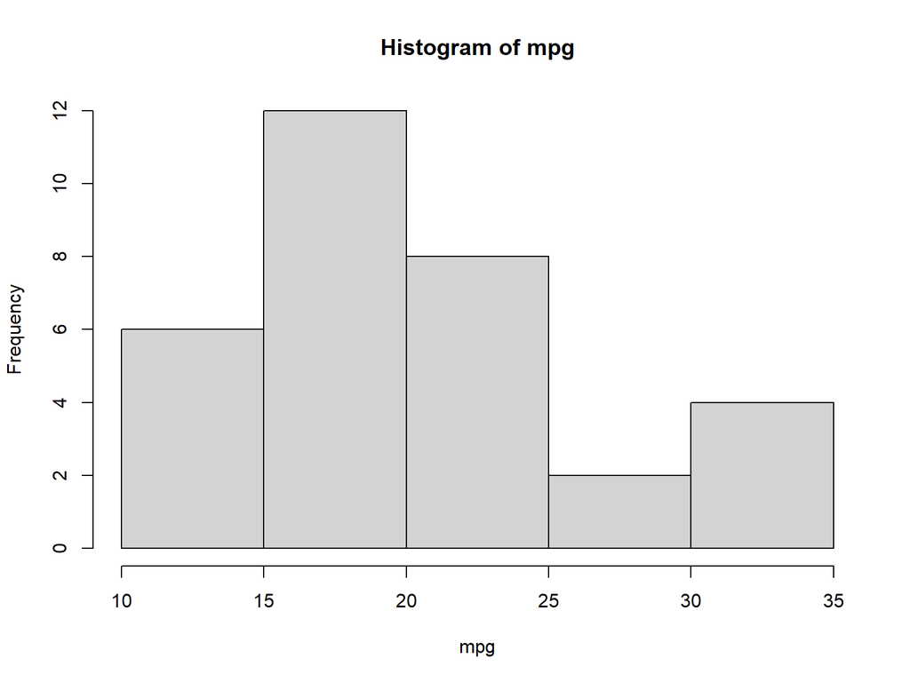

```r
## with() allows you to apply functions to an object with implicit colnames usage
with(mtcars, hist(mpg))
```

# Helpful function **by()**

```r
## by() lets you perform functions on factor levels.
## Let's look at the iris dataset.
head(iris)
```

```
  Sepal.Length Sepal.Width Petal.Length Petal.Width Species
1          5.1         3.5          1.4         0.2  setosa
2          4.9         3.0          1.4         0.2  setosa
3          4.7         3.2          1.3         0.2  setosa
4          4.6         3.1          1.5         0.2  setosa
5          5.0         3.6          1.4         0.2  setosa
6          5.4         3.9          1.7         0.4  setosa
```

```r
## The species column is a factor
class(iris$Species)
```

```
[1] "factor"
```

```r
## Calculate the mean petal width for each species
by(iris, iris$Species, function(x) mean(x$Petal.Width))
```

```
iris$Species: setosa
[1] 0.246
------------------------------------------------------------
iris$Species: versicolor
[1] 1.326
------------------------------------------------------------
iris$Species: virginica
[1] 2.026
```

# Combining Matrices and Vectors with **cbind()** or **rbind()**

```r
## cbind() and rbind() will bind matrices or vectors. The result is an atomic matrix.
## First create a matrix
nums <- matrix(rep(1:10, 10), nrow = 10)
## What does our matrix look like?
nums
```

```
      [,1] [,2] [,3] [,4] [,5] [,6] [,7] [,8] [,9] [,10]
 [1,]    1    1    1    1    1    1    1    1    1     1
 [2,]    2    2    2    2    2    2    2    2    2     2
 [3,]    3    3    3    3    3    3    3    3    3     3
 [4,]    4    4    4    4    4    4    4    4    4     4
 [5,]    5    5    5    5    5    5    5    5    5     5
 [6,]    6    6    6    6    6    6    6    6    6     6
 [7,]    7    7    7    7    7    7    7    7    7     7
 [8,]    8    8    8    8    8    8    8    8    8     8
 [9,]    9    9    9    9    9    9    9    9    9     9
[10,]   10   10   10   10   10   10   10   10   10    10
```

```r
## What are the dimensions?
dim(nums)
```

```
[1] 10 10
```

```r
## Make a new row.
eleven <- rep(11, 10)
## Add a new row to nums.
rbind(nums, eleven)
```

```
       [,1] [,2] [,3] [,4] [,5] [,6] [,7] [,8] [,9] [,10]
          1    1    1    1    1    1    1    1    1     1
          2    2    2    2    2    2    2    2    2     2
          3    3    3    3    3    3    3    3    3     3
          4    4    4    4    4    4    4    4    4     4
          5    5    5    5    5    5    5    5    5     5
          6    6    6    6    6    6    6    6    6     6
          7    7    7    7    7    7    7    7    7     7
          8    8    8    8    8    8    8    8    8     8
          9    9    9    9    9    9    9    9    9     9
         10   10   10   10   10   10   10   10   10    10
eleven   11   11   11   11   11   11   11   11   11    11
```

```r
## Make a new column.
nums_11 <- 10:1
## Add a new column to nums
cbind(nums, nums_11)
```

```
                                    nums_11
 [1,]  1  1  1  1  1  1  1  1  1  1      10
 [2,]  2  2  2  2  2  2  2  2  2  2       9
 [3,]  3  3  3  3  3  3  3  3  3  3       8
 [4,]  4  4  4  4  4  4  4  4  4  4       7
 [5,]  5  5  5  5  5  5  5  5  5  5       6
 [6,]  6  6  6  6  6  6  6  6  6  6       5
 [7,]  7  7  7  7  7  7  7  7  7  7       4
 [8,]  8  8  8  8  8  8  8  8  8  8       3
 [9,]  9  9  9  9  9  9  9  9  9  9       2
[10,] 10 10 10 10 10 10 10 10 10 10       1
```

# **Quick summary of useful functions**

- head() : shows first few rows (n = 6 by default)
- tail() : shows last few rows (n = 6 by default)
- dim() : returns the dimensions of data frame (i.e. number of rows and number of columns)
- nrow() : number of rows
- ncol() : number of columns
- str() : structure of data frame - name, type and preview of data in each column
- names() or colnames() : both show the names attribute for a data frame
- class() : returns data type of object